# Multivariate analysis

```python
# Import Libraries panda
import pandas as pd #data preprocessing
import matplotlib.pyplot as plt #data visualisation
import seaborn as sns #data visualisation
import missingno as msno # Missing data-#data visualisation
from collections import Counter # Counting use capital C
```

```python
# Load data set dataframe means a table called df put 'r' infront of the file path you copied

df= pd.read_csv(r"C:\Users\22077\Downloads\Dune Sales Data.csv")
```

```python
df["Date"] = pd.to_datetime(df["Date"]) # df==data table, pd==pandas, to_datetime is the command
df.info()
```

```
<class 'pandas.core.frame.DataFrame'>
RangeIndex: 34867 entries, 0 to 34866
Data columns (total 12 columns):
 #   Column            Non-Null Count  Dtype
---  ------            --------------  -----
 0   Date              34866 non-null  datetime64[ns]
 1   Customer          34866 non-null  object
 2   Sales Person      34866 non-null  object
 3   Customer_Age      34867 non-null  int64
 4   Customer_Gender   34866 non-null  object
 5   State             34866 non-null  object
 6   Product_Category  34866 non-null  object
 7   Sub_Category      34866 non-null  object
 8   Payment Option    34866 non-null  object
 9   Quantity          34866 non-null  float64
 10  Unit_Cost         34866 non-null  float64
 11  Unit_Price        34866 non-null  float64
dtypes: datetime64[ns](1), float64(3), int64(1), object(7)
memory usage: 3.2+ MB
```

```python
df['year'] = df['Date'].dt.year
df['month'] = df['Date'].dt.month
df['month_name'] = df['Date'].dt.month_name()
df['quarter'] = df['Date'].dt.quarter

df.head(2) ## Now the tabel has date in month names and quarters
```

|  | Date | Customer | Sales Person | Customer_Age | Customer_Gender | State | Product_Category | Sub_Category | Payment Option | Quantity | Unit_Cost | Unit_Price | year | month | month_name | quarter |
| --- | --- | --- | --- | --- | --- | --- | --- | --- | --- | --- | --- | --- | --- | --- | --- | --- |
| 0 | 2016-02-19 | High | Segun | 29 | F | Abia | Accessories | Keyboard | Online | 1.0 | 80.0 | 109.0 | 2016.0 | 2.0 | February | 1.0 |
| 1 | 2016-02-20 | High | Segun | 29 | F | Abia | Clothing | Polo shirts | Online | 2.0 | 24.5 | 28.5 | 2016.0 | 2.0 | February | 1.0 |

```python
def age_group(x):
    if x <= 25:
        return "<= 25 Youth"
    elif x <= 40:
        return "26 - 40 Young Adult"
    elif x <= 60:
        return "46 - 60 Older Adult"
    else:
        return ">60 Elders"

## Apply function to data using the statement [.apply(age_group)]
#create another colunm for age


df['age_group'] = df['Customer_Age'].apply(age_group)
df.head(5) # to show the new data and column name
```

|  | Date | Customer | Sales Person | Customer_Age | Customer_Gender | State | Product_Category | Sub_Category | Payment Option | Quantity | Unit_Cost | Unit_Price | year | month | month_name | quarter | age_group |
| --- | --- | --- | --- | --- | --- | --- | --- | --- | --- | --- | --- | --- | --- | --- | --- | --- | --- |
| 0 | 2016-02-19 | High | Segun | 29 | F | Abia | Accessories | Keyboard | Online | 1.0 | 80.00 | 109.00 | 2016.0 | 2.0 | February | 1.0 | 26 - 40 Young Adult |
| 1 | 2016-02-20 | High | Segun | 29 | F | Abia | Clothing | Polo shirts | Online | 2.0 | 24.50 | 28.50 | 2016.0 | 2.0 | February | 1.0 | 26 - 40 Young Adult |
| 2 | 2016-02-27 | High | Segun | 29 | F | Abia | Accessories | Keyboard | Online | 3.0 | 3.67 | 5.00 | 2016.0 | 2.0 | February | 1.0 | 26 - 40 Young Adult |
| 3 | 2016-03-12 | High | Segun | 29 | F | Abia | Accessories | Keyboard | Online | 2.0 | 87.50 | 116.50 | 2016.0 | 3.0 | March | 1.0 | 26 - 40 Young Adult |
| 4 | 2016-03-12 | High | Segun | 29 | F | Abia | Accessories | Keyboard | Online | 3.0 | 35.00 | 41.67 | 2016.0 | 3.0 | March | 1.0 | 26 - 40 Young Adult |

```python
## Let us calculate Profit and Loss
#Quantity, Revenue and Profit

# create a new column for cost
# total cost(cost) = quantity * unit cost
# revenue = quantity * unit price
# profit = revenue - cost


df['cost'] = df['Quantity'] * df['Unit_Cost']
df['revenue'] = df['Quantity'] * df['Unit_Price']
df['profit'] = df['revenue'] - df['cost']

df.head(3)
```

|  | Date | Customer | Sales Person | Customer_Age | Customer_Gender | State | Product_Category | Sub_Category | Payment Option | Quantity | Unit_Cost | Unit_Price | year | month | month_name | quarter | age_group | cost | revenue | profit |
| --- | --- | --- | --- | --- | --- | --- | --- | --- | --- | --- | --- | --- | --- | --- | --- | --- | --- | --- | --- | --- |
| 0 | 2016-02-19 | High | Segun | 29 | F | Abia | Accessories | Keyboard | Online | 1.0 | 80.00 | 109.0 | 2016.0 | 2.0 | February | 1.0 | 26 - 40 Young Adult | 80.00 | 109.0 | 29.00 |
| 1 | 2016-02-20 | High | Segun | 29 | F | Abia | Clothing | Polo shirts | Online | 2.0 | 24.50 | 28.5 | 2016.0 | 2.0 | February | 1.0 | 26 - 40 Young Adult | 49.00 | 57.0 | 8.00 |
| 2 | 2016-02-27 | High | Segun | 29 | F | Abia | Accessories | Keyboard | Online | 3.0 | 3.67 | 5.0 | 2016.0 | 2.0 | February | 1.0 | 26 - 40 Young Adult | 11.01 | 15.0 | 3.99 |

```python
def porl(x):
    if x < 0:
        return 'loss'
    else:
        return 'profit'

df['profit_loss_label'] = df['profit'].apply(porl)
df.head(3)
```

|  | Date | Customer | Sales Person | Customer_Age | Customer_Gender | State | Product_Category | Sub_Category | Payment Option | Quantity | ... | Unit_Price | year | month | month_name | quarter | age_group | cost | revenue | profit | profit_loss_label |
| --- | --- | --- | --- | --- | --- | --- | --- | --- | --- | --- | --- | --- | --- | --- | --- | --- | --- | --- | --- | --- | --- |
| 0 | 2016-02-19 | High | Segun | 29 | F | Abia | Accessories | Keyboard | Online | 1.0 | ... | 109.0 | 2016.0 | 2.0 | February | 1.0 | 26 - 40 Young Adult | 80.00 | 109.0 | 29.00 | profit |
| 1 | 2016-02-20 | High | Segun | 29 | F | Abia | Clothing | Polo shirts | Online | 2.0 | ... | 28.5 | 2016.0 | 2.0 | February | 1.0 | 26 - 40 Young Adult | 49.00 | 57.0 | 8.00 | profit |
| 2 | 2016-02-27 | High | Segun | 29 | F | Abia | Accessories | Keyboard | Online | 3.0 | ... | 5.0 | 2016.0 | 2.0 | February | 1.0 | 26 - 40 Young Adult | 11.01 | 15.0 | 3.99 | profit |

3 rows × 21 columns

```python
df.columns
```

```
Index(['Date', 'Customer', 'Sales Person', 'Customer_Age', 'Customer_Gender',
       'State', 'Product_Category', 'Sub_Category', 'Payment Option',
       'Quantity', 'Unit_Cost', 'Unit_Price', 'year', 'month', 'month_name',
       'quarter', 'age_group', 'cost', 'revenue', 'profit',
       'profit_loss_label'],
      dtype='object')
```

## Multivaraite Analysis

- It involves analysing the realtioship between three or more varaiables

```python
procat = df.groupby("Product_Category")[['cost', 'revenue', 'profit']].sum().reset_index()
```

```python
procat
```

|  | Product_Category | cost | revenue | profit |
| --- | --- | --- | --- | --- |
| 0 | Accessories | 6041896.06 | 7420663.12 | 1378767.06 |
| 1 | Clothing | 2892324.94 | 3437556.95 | 545232.01 |
| 2 | Phones | 11148745.02 | 11486354.63 | 337609.61 |

```python
# We want to transpose the data in procat above to assign Metric to cost, revenue and profit
# this will make visualisation easy
# we use the pd.melt # pd is pandas
#var_name means variable name/column name
# three columns are formed here 'Product Category, Metric, and Total'

procat1 = pd.melt(procat, id_vars="Product_Category", var_name="Metric", value_name="Total")

procat1
```

|  | Product_Category | Metric | Total |
| --- | --- | --- | --- |
| 0 | Accessories | cost | 6041896.06 |
| 1 | Clothing | cost | 2892324.94 |
| 2 | Phones | cost | 11148745.02 |
| 3 | Accessories | revenue | 7420663.12 |
| 4 | Clothing | revenue | 3437556.95 |
| 5 | Phones | revenue | 11486354.63 |
| 6 | Accessories | profit | 1378767.06 |
| 7 | Clothing | profit | 545232.01 |
| 8 | Phones | profit | 337609.61 |

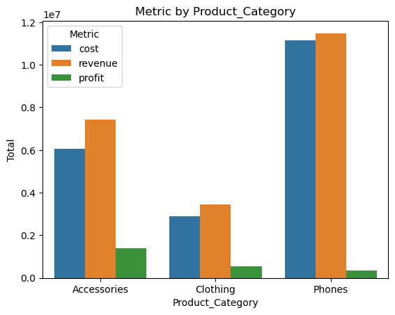

```python
#Visualisation

procat = df.groupby("Product_Category")[['cost', 'revenue', 'profit']].sum().reset_index() # to generate procat above

procat1 = pd.melt(procat, id_vars="Product_Category", var_name="Metric", value_name="Total") # to merge profit, cost and reveneu

sns.barplot(data=procat1, x="Product_Category", y="Total", hue="Metric") # to visualise

plt.title('Metric by Product_Category')
plt.show(); # to assign a title
```

# Above chart

- it showed that the company makes highest revenue from phones
- However, the highest profit is made from accessories
- furthermore, phones with the highest revenue generated the least profits
- Continue selling phones to bring more people to the store who may end up buying accessories and make more profit
- we can also check where the highest quantity comes from

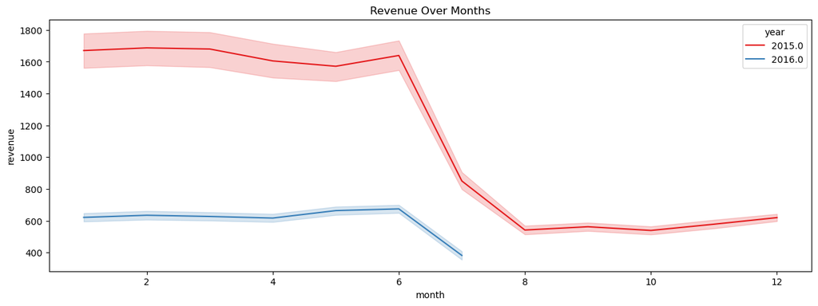

```python
# I look at the revenue by months in both years
# I need to know which month had highest revenue generated
# Then which month had highest profit made

plt.figure(figsize=(15,5))
sns.lineplot(x='month', y='revenue', data=df, hue='year', palette='Set1')
plt.title("Revenue Over Months")
plt.show();
```

# Revenue drops drastically after the mid year and start to rise again from the 11th month

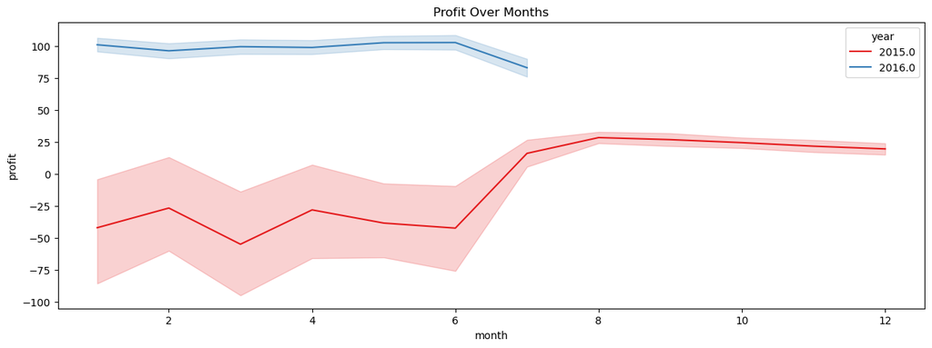

```python
plt.figure(figsize=(15,5))
sns.lineplot(x='month', y='profit', data=df, hue='year', palette='Set1')
plt.title("Profit Over Months")
plt.show();
```

The company is making more profit in 2016 till the 7th month where it started to decline

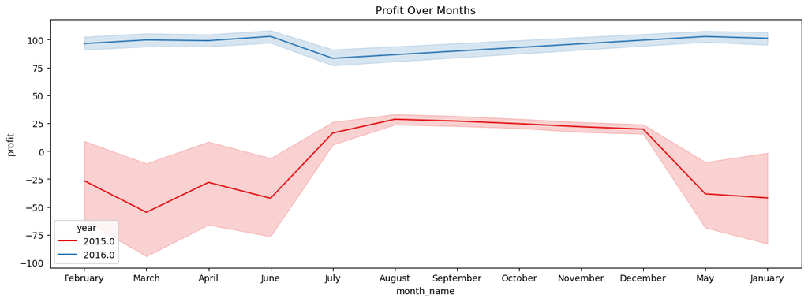

```python
# I want to generate the above visualisation using the month name below

plt.figure(figsize=(15,5))
sns.lineplot(x='month_name', y='profit', data=df, hue='year', palette='Set1')
plt.title("Profit Over Months")
plt.show();
```

```python
# Using a pivot table to explain the profits


df.pivot_table(values='profit', index='year', columns='month', aggfunc='sum')
```

| month year | 1.0 | 2.0 | 3.0 | 4.0 | 5.0 | 6.0 | 7.0 | 8.0 | 9.0 | 10.0 | 11.0 | 12.0 |
| --- | --- | --- | --- | --- | --- | --- | --- | --- | --- | --- | --- | --- |
| 2015.0 | -5778.70 | -4079.65 | -8163.79 | -4945.69 | -7801.45 | -8690.61 | 15104.47 | 65926.24 | 62172.33 | 62950.66 | 54480.9 | 67448.12 |
| 2016.0 | 280204.25 | 263640.18 | 299777.67 | 307746.51 | 356915.59 | 357549.86 | 107151.79 | NaN | NaN | NaN | NaN | NaN |

The company kept making profit sin July 2015 until July 2016 where there is a sharp deline in profit

```python
df.columns
```

```
Index(['Date', 'Customer', 'Sales Person', 'Customer_Age', 'Customer_Gender',
       'State', 'Product_Category', 'Sub_Category', 'Payment Option',
       'Quantity', 'Unit_Cost', 'Unit_Price', 'year', 'month', 'month_name',
       'quarter', 'age_group', 'cost', 'revenue', 'profit',
       'profit_loss_label'],
      dtype='object')
```

```
''
```

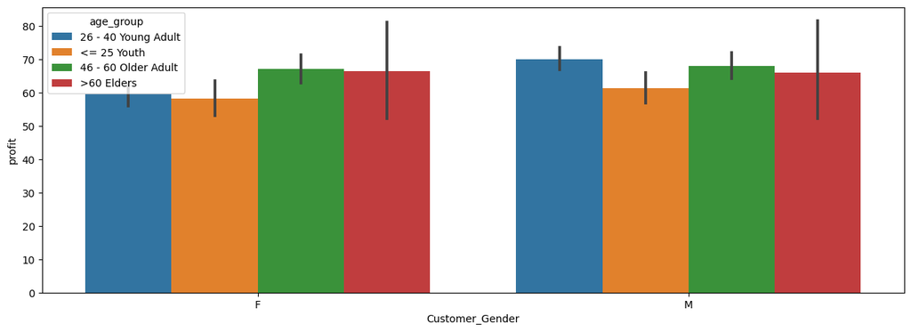

```python
## Let us look now at the customer gender and age gropu generting the highest profit

plt.figure(figsize=(15,5))

sns.barplot(data=df, x='Customer_Gender', y='profit', hue='age_group')
;
```

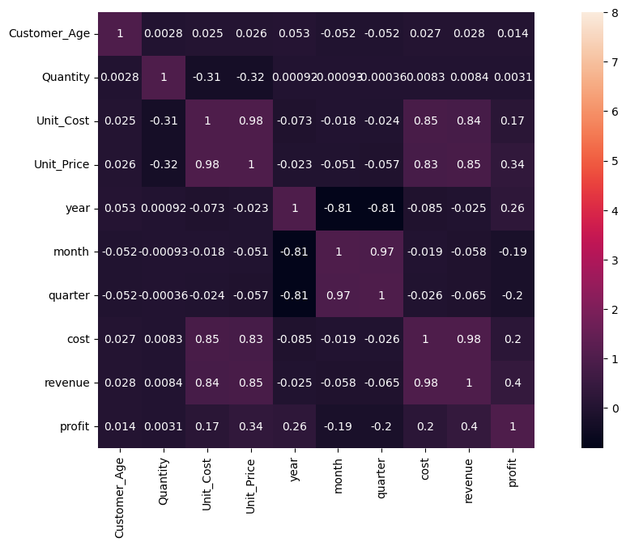

```python
## Correlation

# Examining one column against the other

a = df.corr()

f, ax = plt.subplots(figsize=(15,7))

sns.heatmap(a, vmax=8, square=True, annot=True);
```

# The heat map showed the relationship between the data for the purpose of PREDICTIVE ANALYSIS

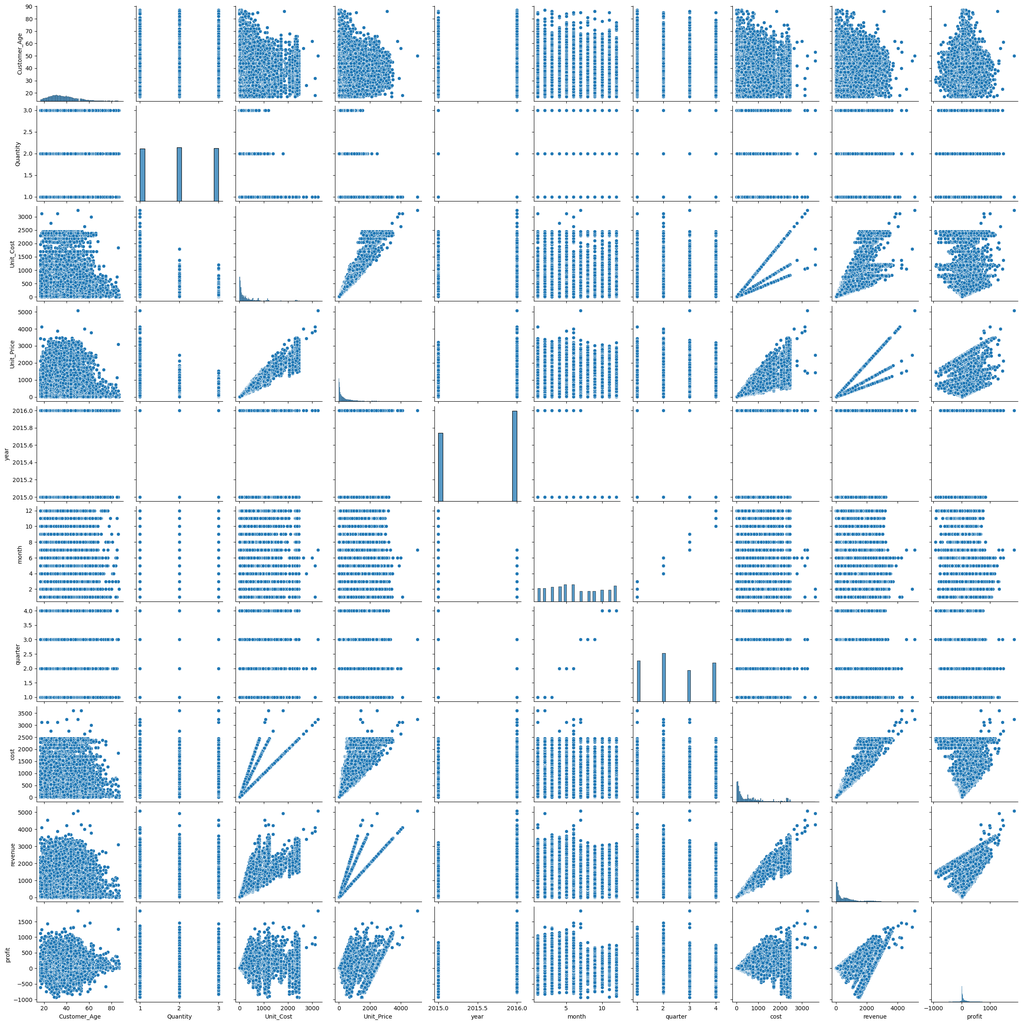

```python
# Pair plot

sns.pairplot(df,size=2.5);
```